# Math 4753 Lab1: Introduction to R

Yangzom Dolma

2021-01-27

# Task 1

The working directory:

```r
getwd()
```

```
## [1] "/Users/yangzomdolma/Desktop/StatsYang0019/Labs/Lab1"
```

# Task 2

First six lines of data.

```r
ddt = read.csv("DDT.csv")
head(ddt)
```

```
##   RIVER MILE  SPECIES LENGTH WEIGHT DDT
## 1   FCM    5 CCATFISH   42.5    732  10
## 2   FCM    5 CCATFISH   44.0    795  16
## 3   FCM    5 CCATFISH   41.5    547  23
## 4   FCM    5 CCATFISH   39.0    465  21
## 5   FCM    5 CCATFISH   50.5   1252  50
## 6   FCM    5 CCATFISH   52.0   1255 150
```

# Task 3

1. The qualitative variables in ddt data set are:

Ans: RIVER and SPECIES.

2. The quantitative variables in the ddt data set are:

Ans: MILE, LENGTH, WEIGHT and DDT.

3. Number of species in the ddt data set.

Ans. 3 Species.

```r
df<-with(ddt, SPECIES)
df_unique<-unique(df)
length(df_unique)
```

```
## [1] 3
```

4. Subset the ddt data set so that we see only the observations with SPECIES, LMBASS and WEIGHT bigger than 800gms.

```r
ddt_subset<-with(ddt, ddt[WEIGHT>800 & SPECIES=="LMBASS",])
head (ddt_subset)
```

```
##     RIVER MILE SPECIES LENGTH WEIGHT DDT
## 141   TRM  345  LMBASS     30    856 2.2
## 144   TRM  345  LMBASS     36   1433 1.9
```

5. Subset the ddt data set so that we see only those observations where the RIVER is SCM and DDT bigger than 4.0

```r
ddt_river <- with(ddt, ddt[DDT > 4.0 & RIVER == "SCM",])
head (ddt_river)
```

```
##    RIVER MILE  SPECIES LENGTH WEIGHT DDT
## 16   SCM    1 CCATFISH     45    984 9.1
## 17   SCM    1 CCATFISH     43    965 7.8
## 18   SCM    1 CCATFISH     45   1084 4.1
```

# Clicker Questions

Q1. The mean length of fish in the ddt data frame.

Ans: 42.81 length unit.

```r
z<-mean(ddt$LENGTH)
z
```

```
## [1] 42.8125
```

Q2. What is the standard deviation of the weight of fish in the ddt data frame?

Ans: 376.5461

```r
x <- sd(ddt$WEIGHT)
x
```

```
## [1] 376.5461
```

Q4. If v=1:20 what is the last value of v/20?

Ans: 1.00

```r
v = 1:20
v/20
```

```
##  [1] 0.05 0.10 0.15 0.20 0.25 0.30 0.35 0.40 0.45 0.50 0.55 0.60 0.65 0.70 0.75
## [16] 0.80 0.85 0.90 0.95 1.00
```

# Task 4: Table and Barplot

1. Table of the rivers.

```r
RiverTable = table(ddt$RIVER)
print(RiverTable)
```

```
##
## FCM LCM SCM TRM
##   6   6   6 126
```

2. Color coded barplot of the rivers.

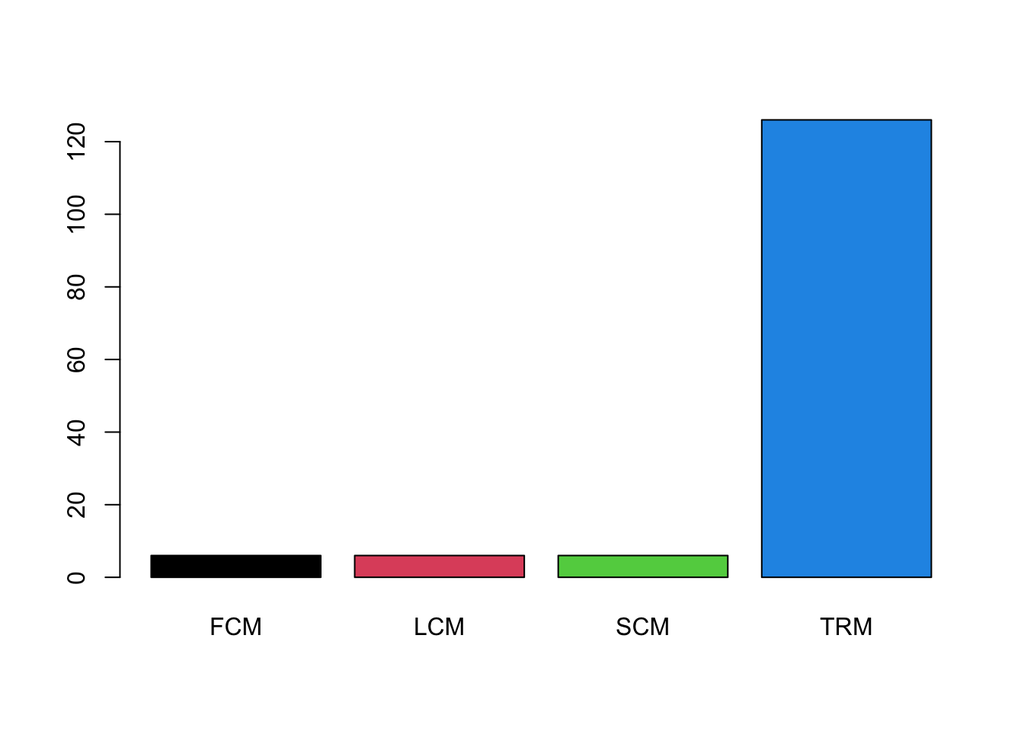

```r
barplot(table(ddt$RIVER), col = 1:4)
```

3. Table of the RIVERS crossed with the SPECIES of fish.

```r
tableRS <- with(ddt, table(SPECIES, RIVER))
print(tableRS)
```

```
##            RIVER
## SPECIES     FCM LCM SCM TRM
##   CCATFISH    6   6   6  78
##   LMBASS      0   0   0  12
##   SMBUFFALO   0   0   0  36
```

4. Barplot of the RIVER crossed with the SPECIES of fish.

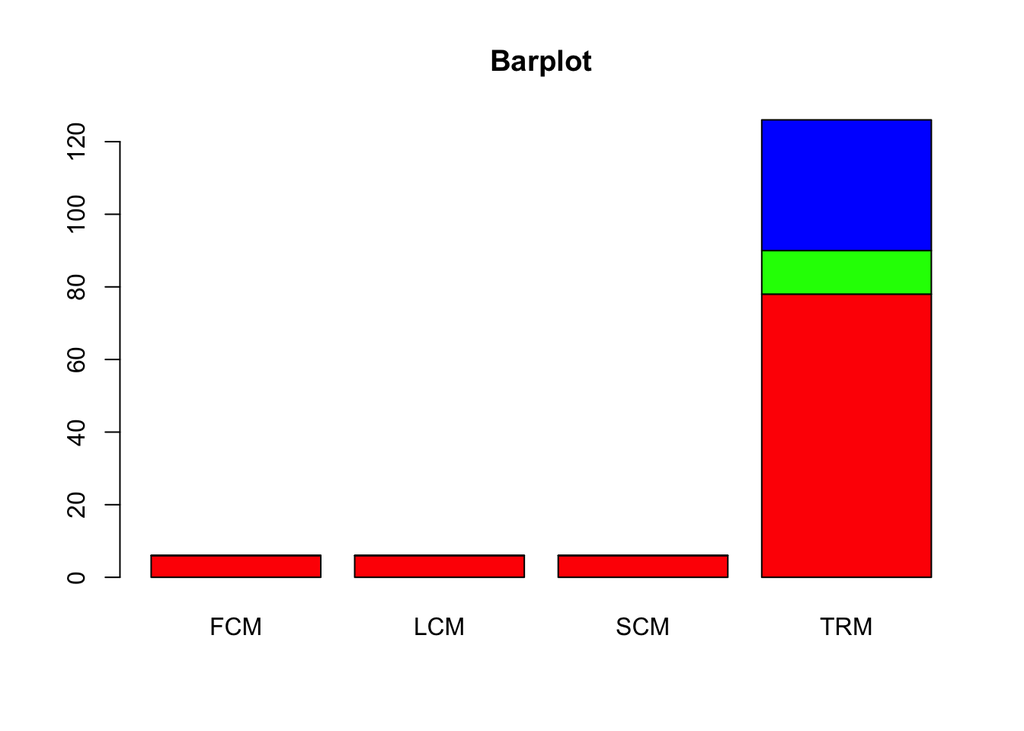

```r
barplot(tableRS, col = rainbow(3),
        main = "Barplot",
        border = "Black"
        )
```

# Task 5: Pie Chart

1. Pie chart of Fish SPECIES

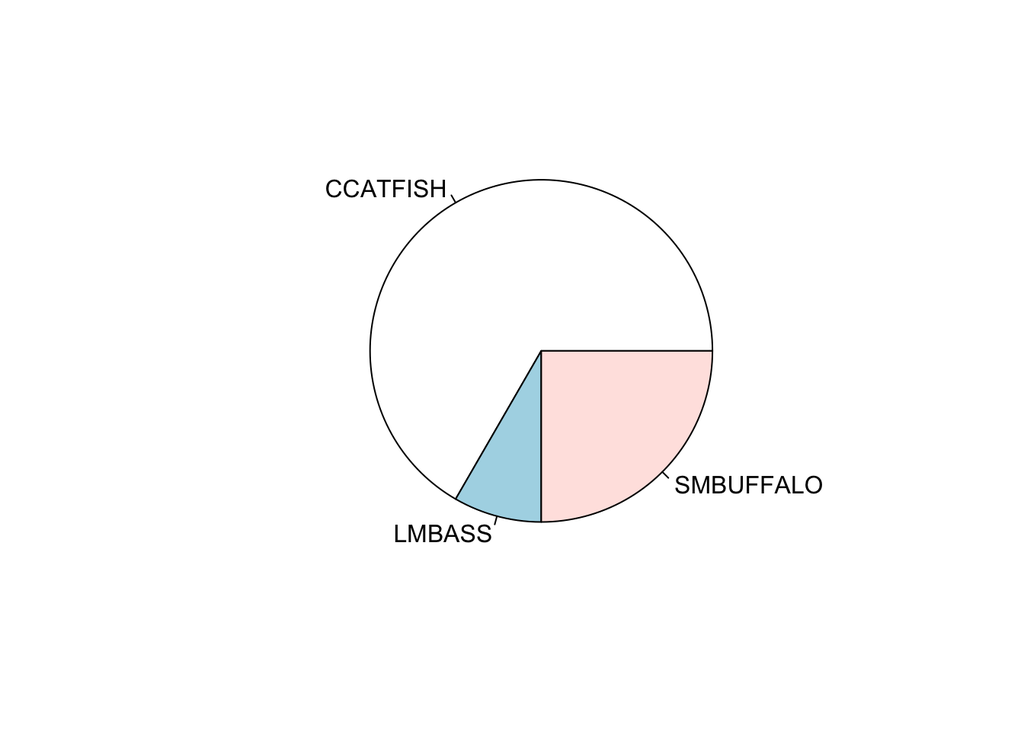

```r
fish = ddt$SPECIES
pie (table(fish))
```

2. Pie chart of RIVERS

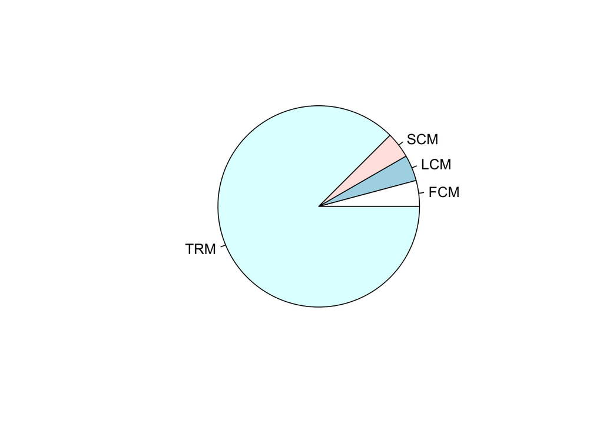

```r
rivers = ddt$RIVER
pie (table(rivers))
```

# Task 6: Boxplot

1. Boxplot of the variable DDT

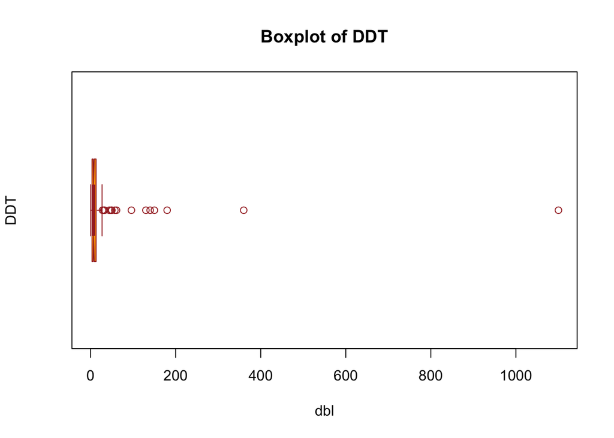

```r
boxplot(ddt$DDT,
        main = "Boxplot of DDT",
        xlab = "dbl",
        ylab = "DDT",
        col = "Orange",
        border = "brown",
        horizontal = TRUE,
        notch = TRUE
)
```

2. Boxplot of the variable WEIGHT

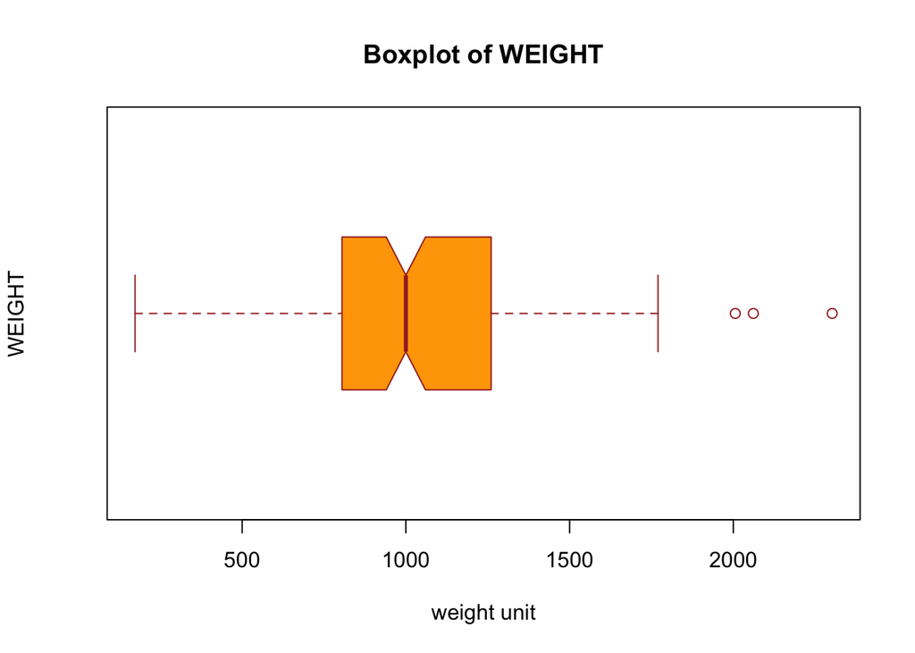

```r
boxplot(ddt$WEIGHT,
        main = "Boxplot of WEIGHT",
        xlab = "weight unit",
        ylab = "WEIGHT",
        col = "Orange",
        border = "brown",
        horizontal = TRUE,
        notch = TRUE
)
```

3. Boxplot of the variable LENGTH

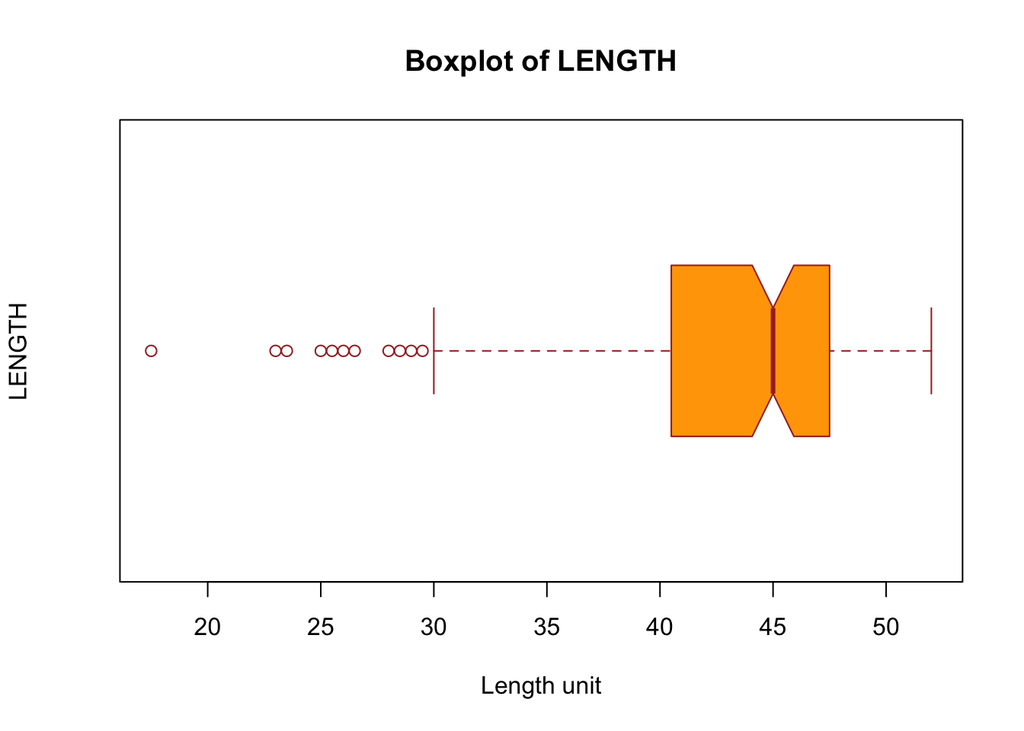

```r
boxplot(ddt$LENGTH,
        main = "Boxplot of LENGTH",
        xlab = "Length unit",
        ylab = "LENGTH",
        col = "Orange",
        border = "brown",
        horizontal = TRUE,
        notch = TRUE
)
```

# Task 7: Coplot

1. Coplot of LENGTH Vs WEIGHT given RIVER

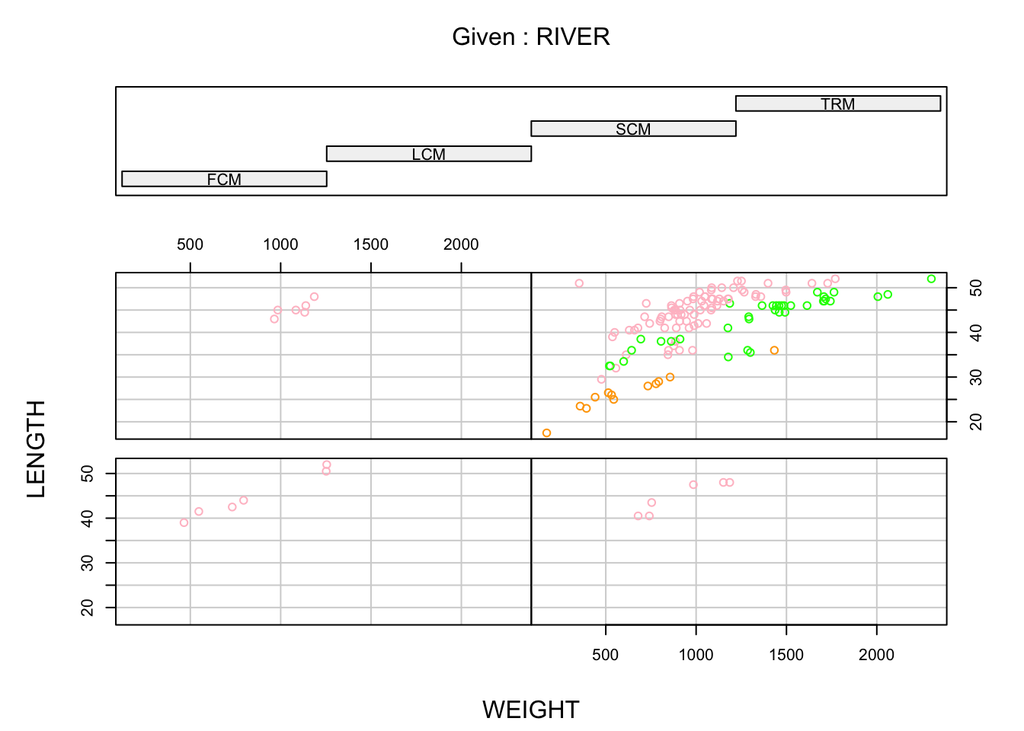

```r
coplot(LENGTH ~ WEIGHT | RIVER,
       data=ddt,
       col = with(ddt, ifelse (SPECIES == "CCATFISH", "Pink",
                  ifelse(SPECIES == "SMBUFFALO", "Green", "Orange"))))
```

2. Coplot of DDT vs WEIGHT given SPECIES

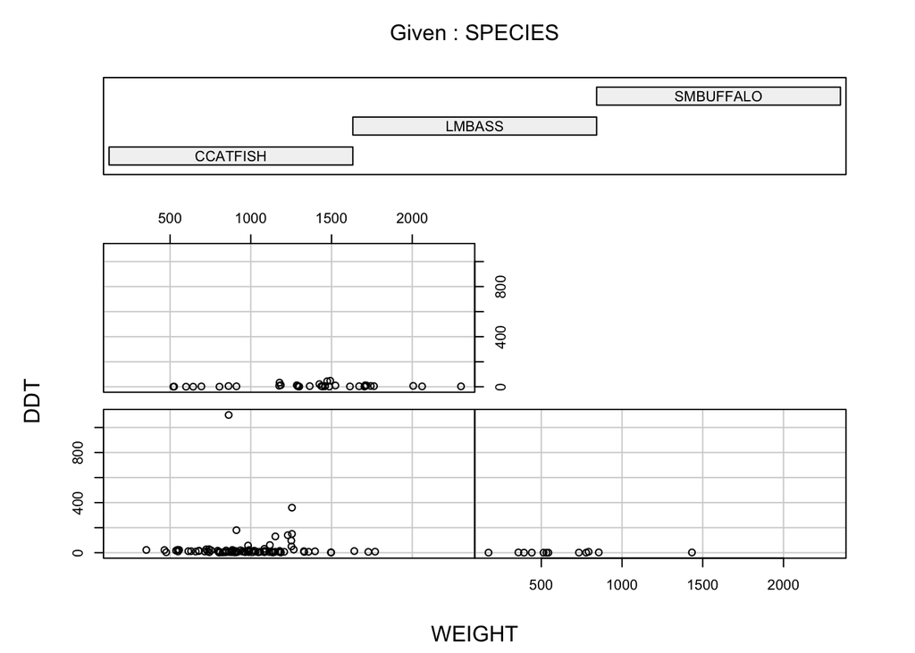

```r
coplot(DDT ~ WEIGHT | SPECIES, data = ddt)
```

# Task 8: ggplot: Box, Violin, Scatter

1. ggplot: Boxplot for WEIGHT vs SPECIES

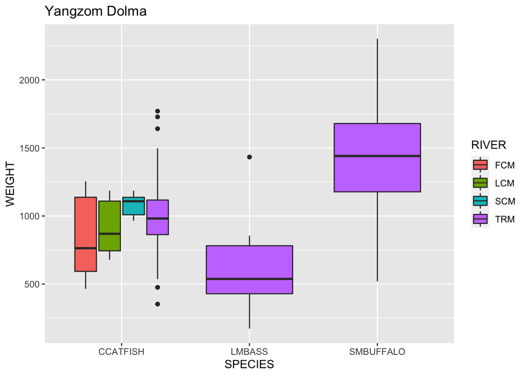

```r
library(ggplot2)
ggplot(ddt, ggplot2::aes(x=SPECIES, y=WEIGHT)) + geom_boxplot(aes(fill=RIVER)) + ggtitle("Yangzom Dolma")
```

b. ggplot: Violin Plot for LENGTH vs RIVER

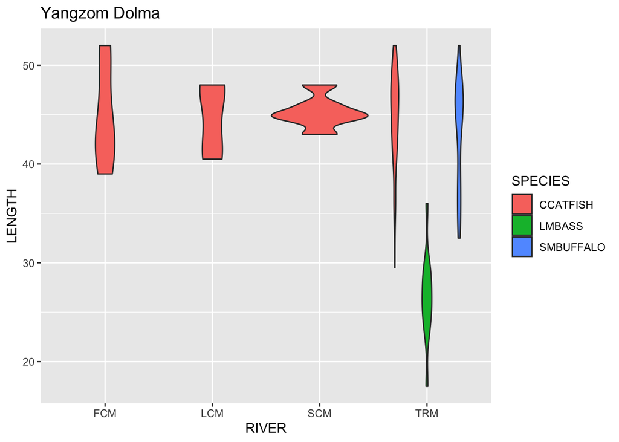

```r
print(ggplot(ddt, aes(x=RIVER, y = LENGTH)) + geom_violin(aes(fill =SPECIES)) + ggtitle("Yangzom Dolma"))
```

c. ggplot: Scatter Plot for LENGTH vs WEIGHT

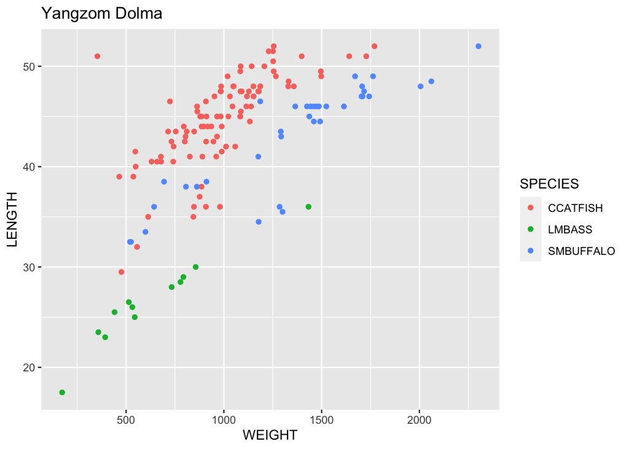

```r
ggsc = ggplot(ddt, aes(x= WEIGHT, y = LENGTH))

ggsc = ggsc + geom_point(aes(color = SPECIES)) + ggtitle("Yangzom Dolma")

print(ggsc)
```